# Comparing arima, ets and OLS with and without hierarchy process - Wikipedia Pageviews

August 20, 2018

## Six methods:

1. Forecasting hierarchical time series using **optimal combination reconciliation** with **arima** bottom level forecast
2. Forecasting hierarchical time series using **optimal combination reconciliation** with **ets** bottom level forecast
3. Forecasting hierarchical time series using **optimal combination reconciliation** with **OLS** bottom level forecast
4. Forecasting time series using **arima** models
5. Forecasting time series using **ets** models
6. Forecasting time series using **OLS** models

## WikipediaData: Comparing all methods - with and without hierarchy - mean(log(RMSE))

| Method | Mean(log(RMSE)) |
| --- | --- |
| arima | -0.103 |
| Hierarchy-arima | -0.152 |
| ets | -0.45 |
| Hierarchy-ets | -0.408 |
| OLS | 0.092 |
| Hierarchy-OLS | 2.228 |

## WikipediaData: Comparing three hierarchy methods - log(RMSE) Density plot

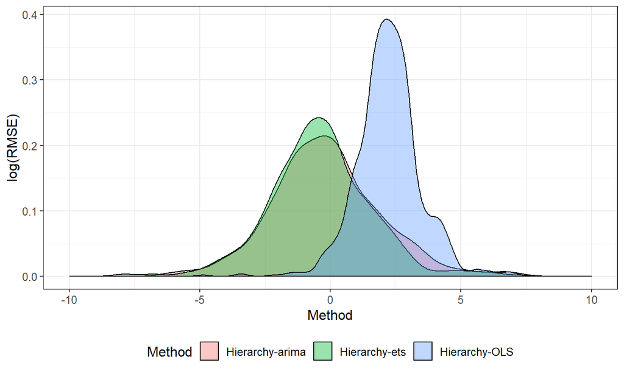

## WikipediaData: Comparing three hierarchy methods - log(RMSE) Boxplot

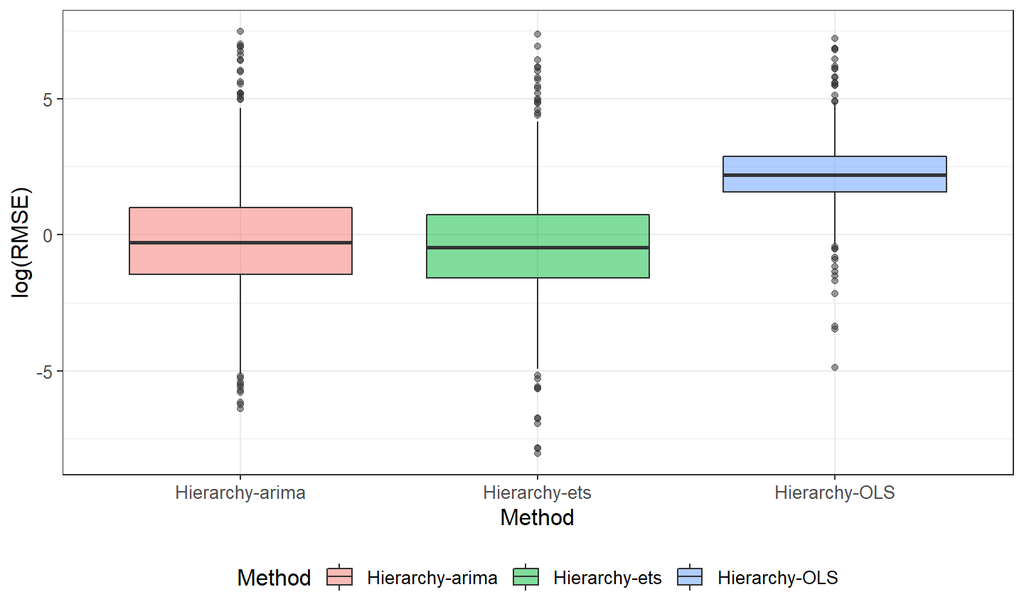

## WikipediaData: Comparing three hierarchy methods - Subtracted log(RMSE) Boxplot

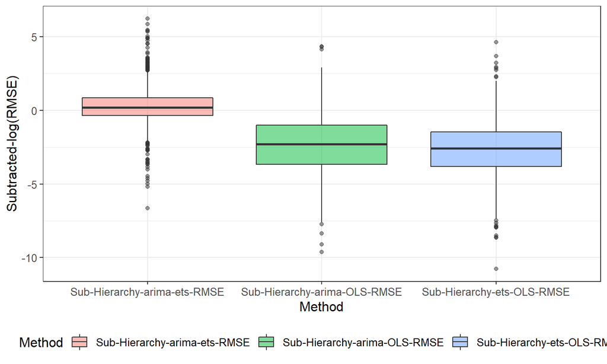

## WikipediaData: Comparing three hierarchy methods - Error Density plot

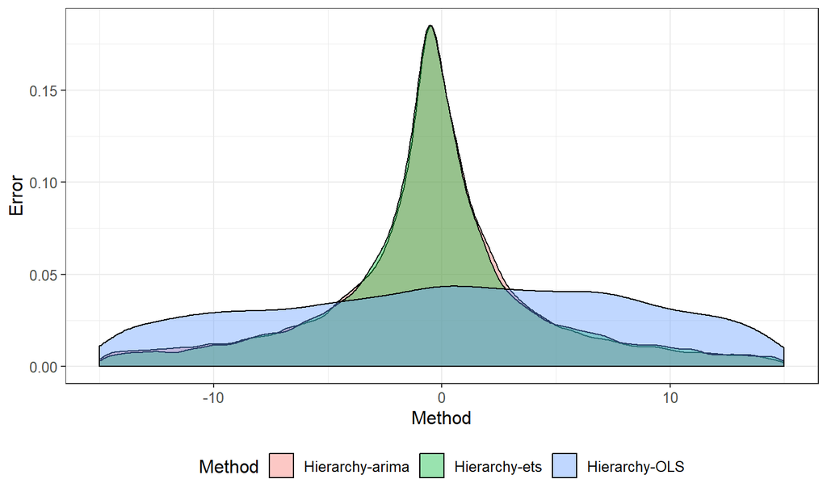

## WikipediaData: Comparing three hierarchy methods - Error Boxplot

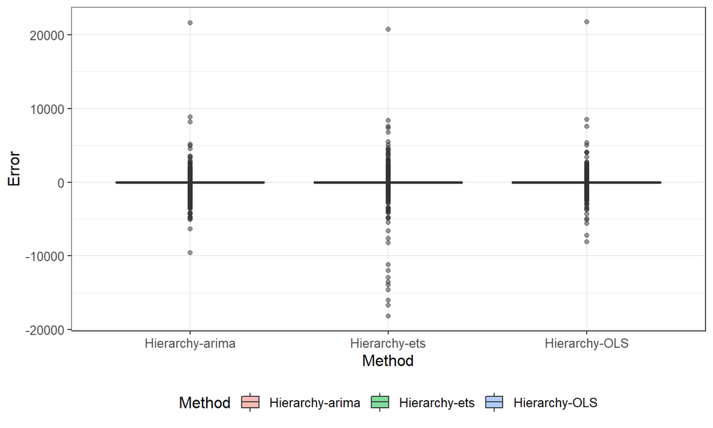

## WikipediaData: Comparing three hierarchy methods - Subtracted Error Boxplot

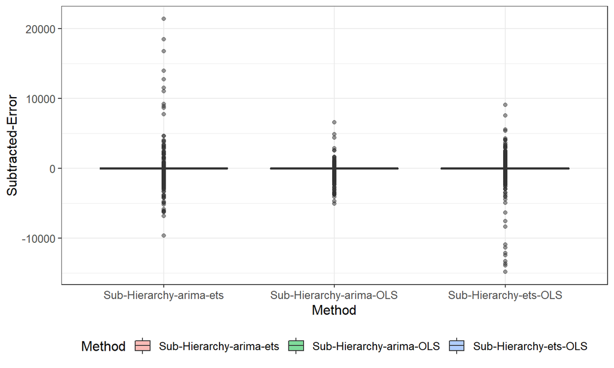

## WikipediaData: Comparing three hierarchy methods - Forecasted Series Plot

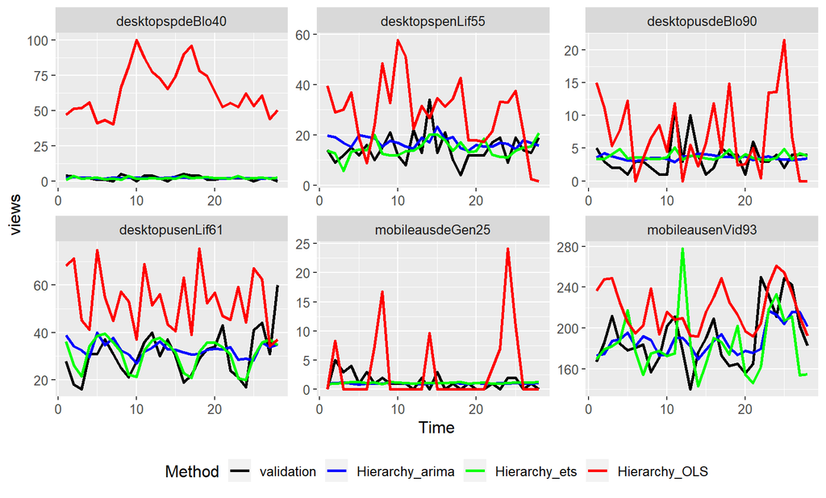

## WikipediaData: Comparing three methods - without hierarchy - log(RMSE) Density plot

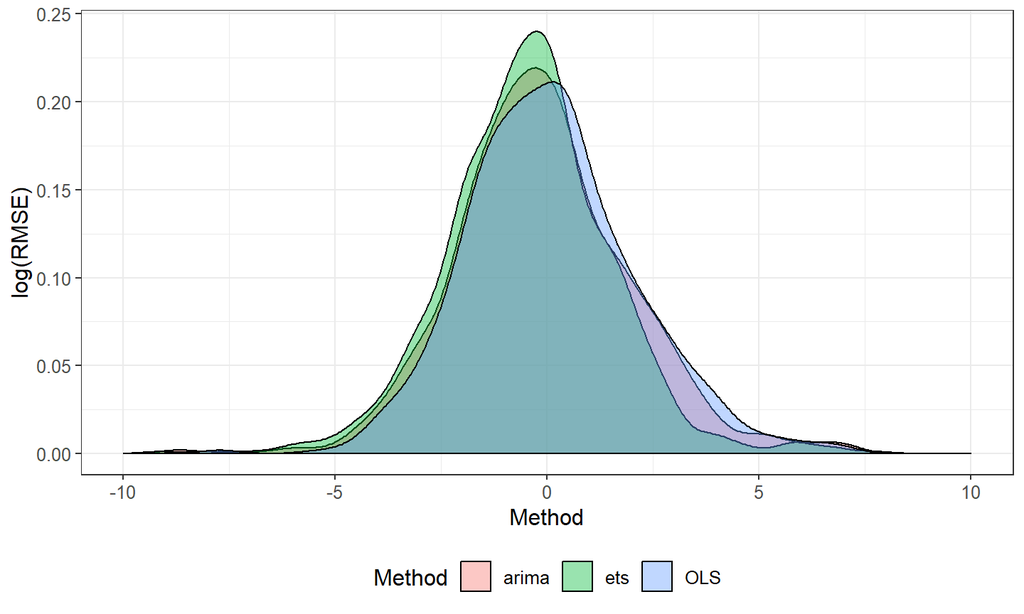

## WikipediaData: Comparing three methods - without hierarchy - log(RMSE) Boxplot

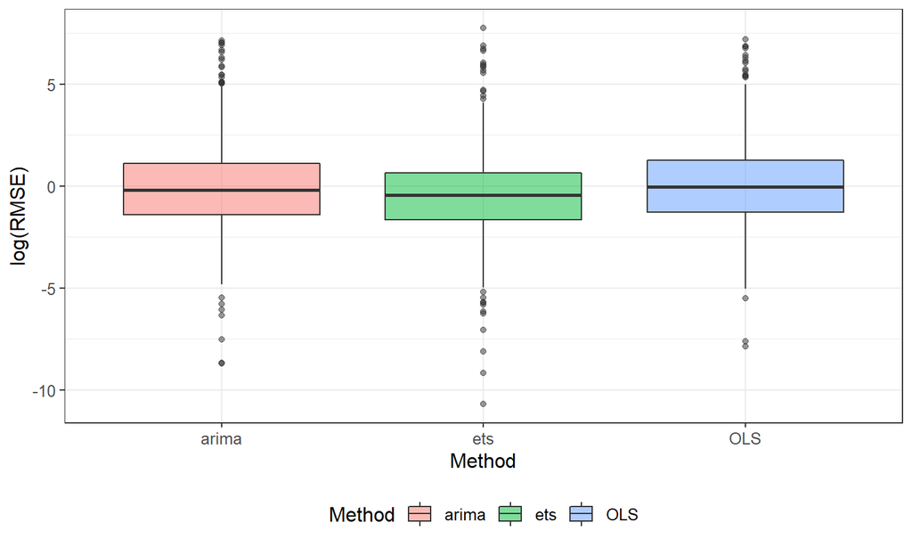

## WikipediaData: Comparing three methods - without hierarchy - Subtracted log(RMSE) Boxplot

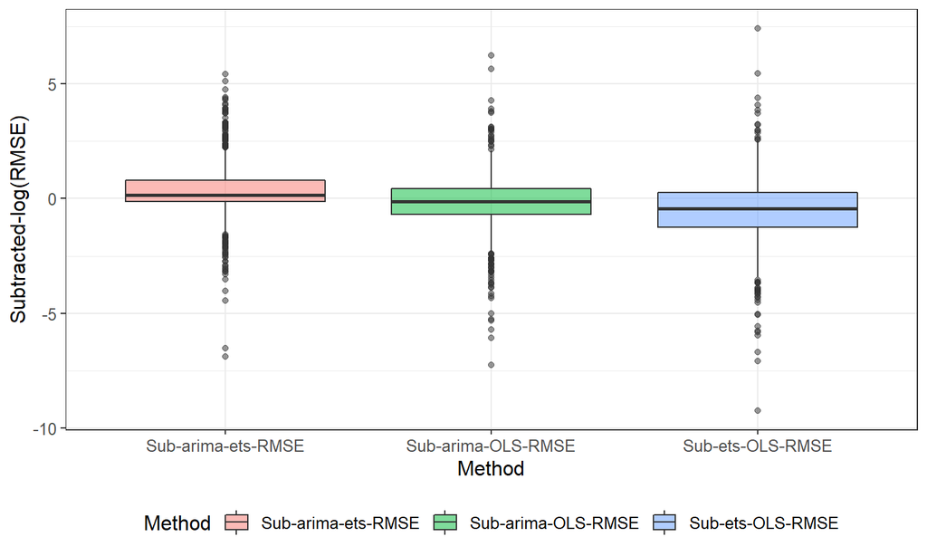

## WikipediaData: Comparing three methods - without hierarchy - Error Density plot

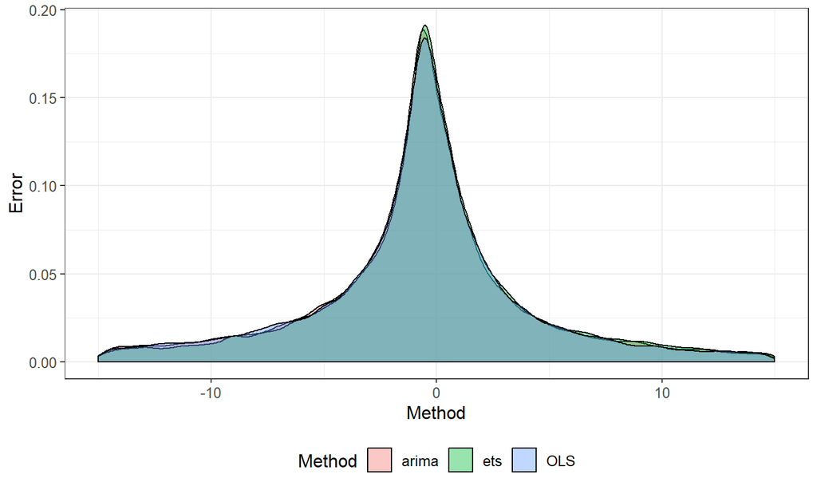

## WikipediaData: Comparing three methods - without hierarchy - Error Boxplot

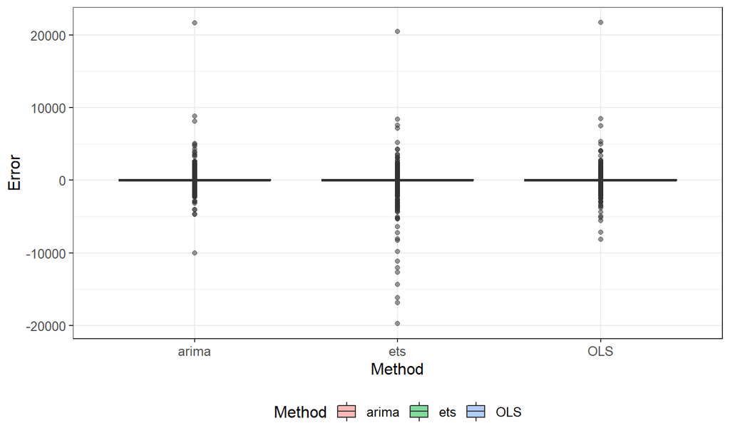

## WikipediaData: Comparing three methods - without hierarchy- Subtracted Error Boxplot

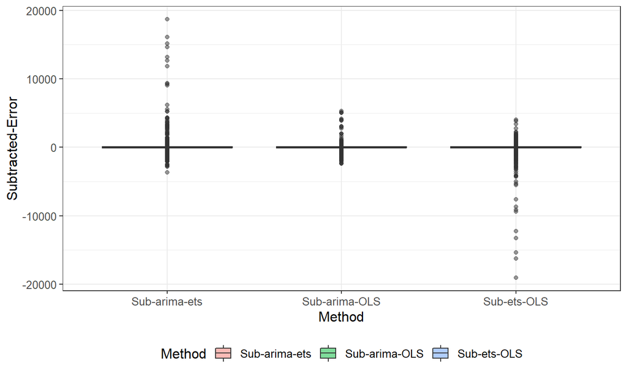

## WikipediaData: Comparing three methods - without hierarchy - Forecasted Series Plot

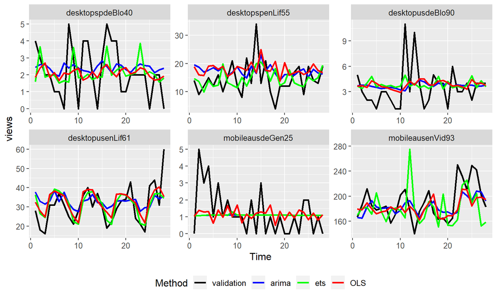

## WikipediaData: Comparing arima methods - with and without hierarchy - log(RMSE) Density plot

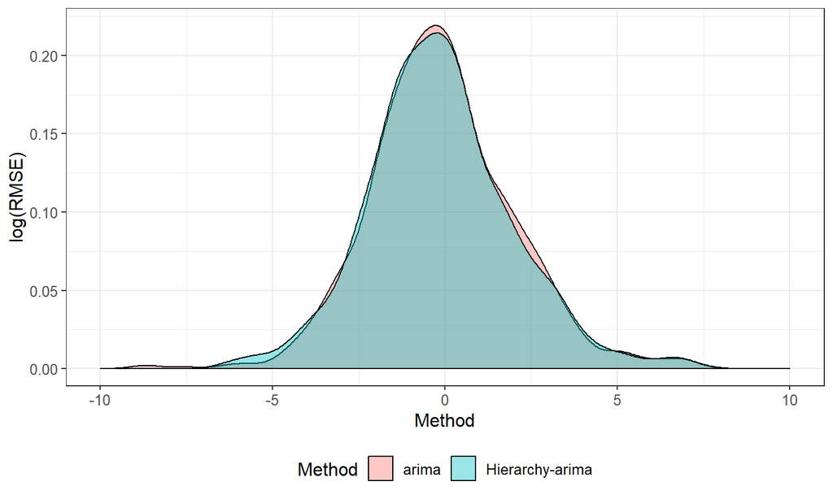

## WikipediaData: Comparing arima methods - with and without hierarchy - log(RMSE) Boxplot

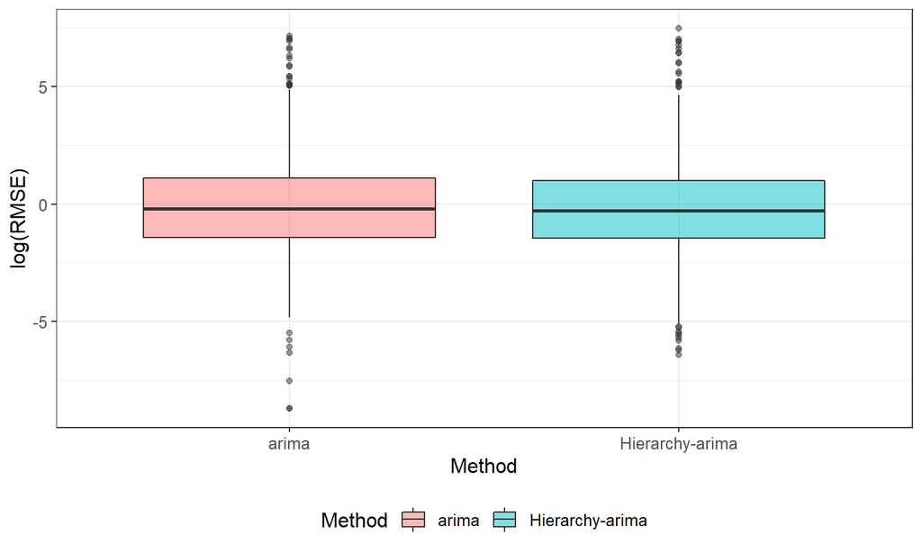

## WikipediaData: Comparing arima methods - with and without hierarchy - Subtracted log(RMSE) Boxplot

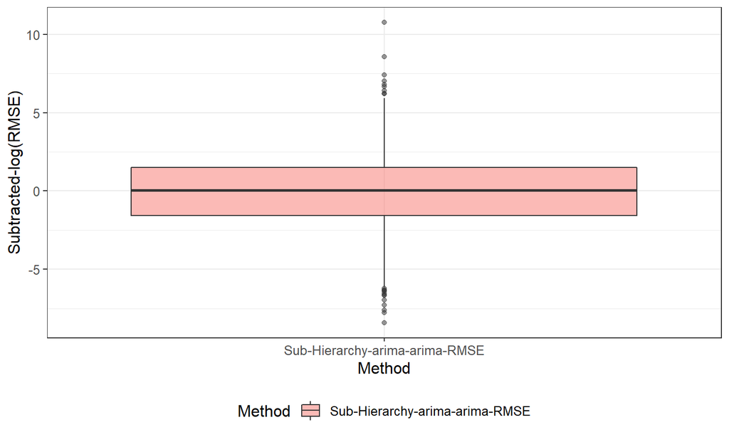

## WikipediaData: Comparing arima methods - with and without hierarchy - Error Density plot

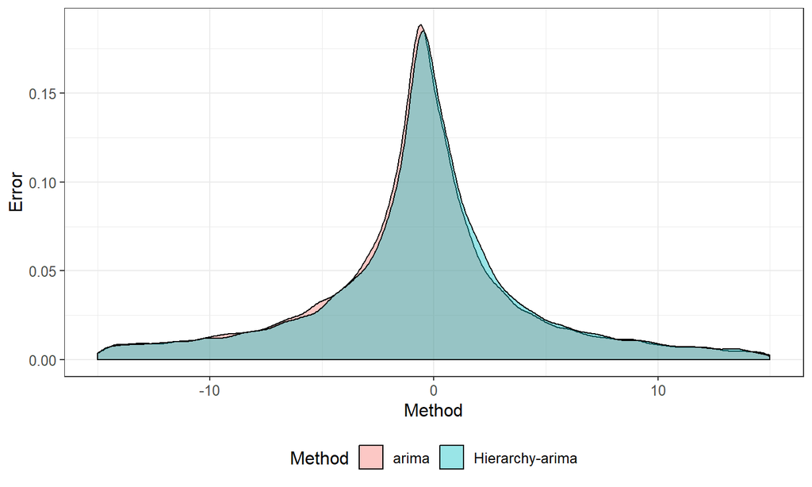

## WikipediaData: Comparing arima methods - with and without hierarchy - Error Boxplot

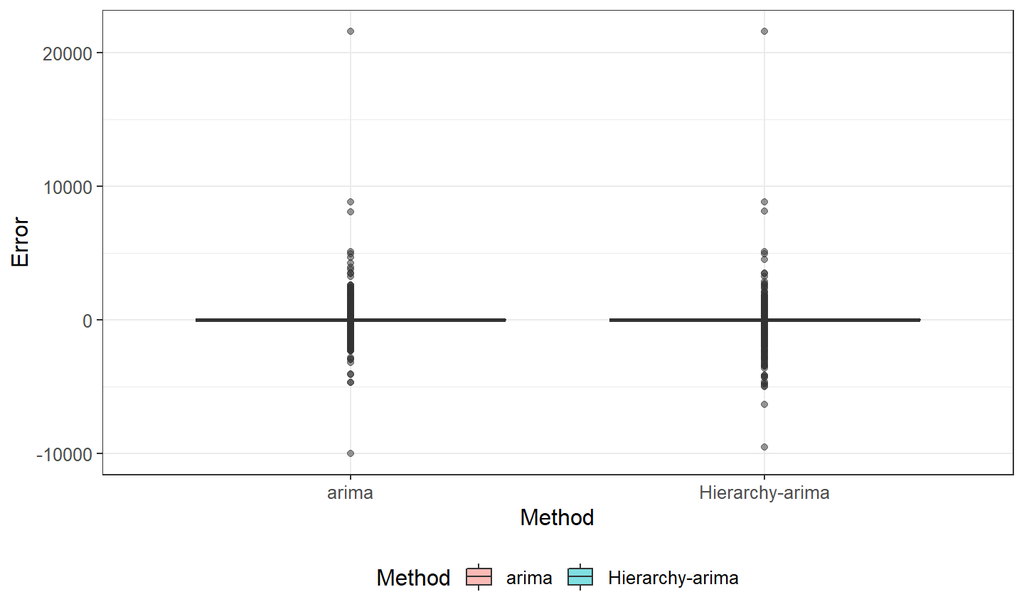

## WikipediaData: Comparing arima methods - with and without hierarchy - Subtracted Error Boxplot

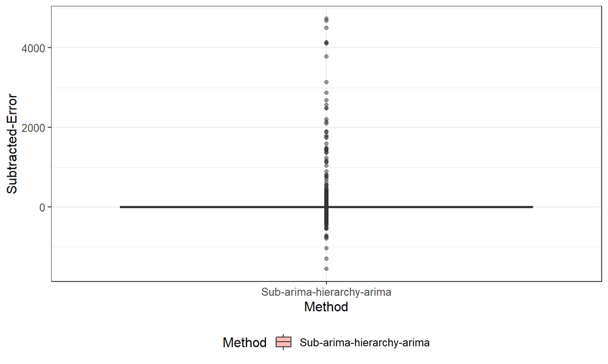

## WikipediaData: Comparing arima methods - with and without hierarchy - Forecasted Series Plot

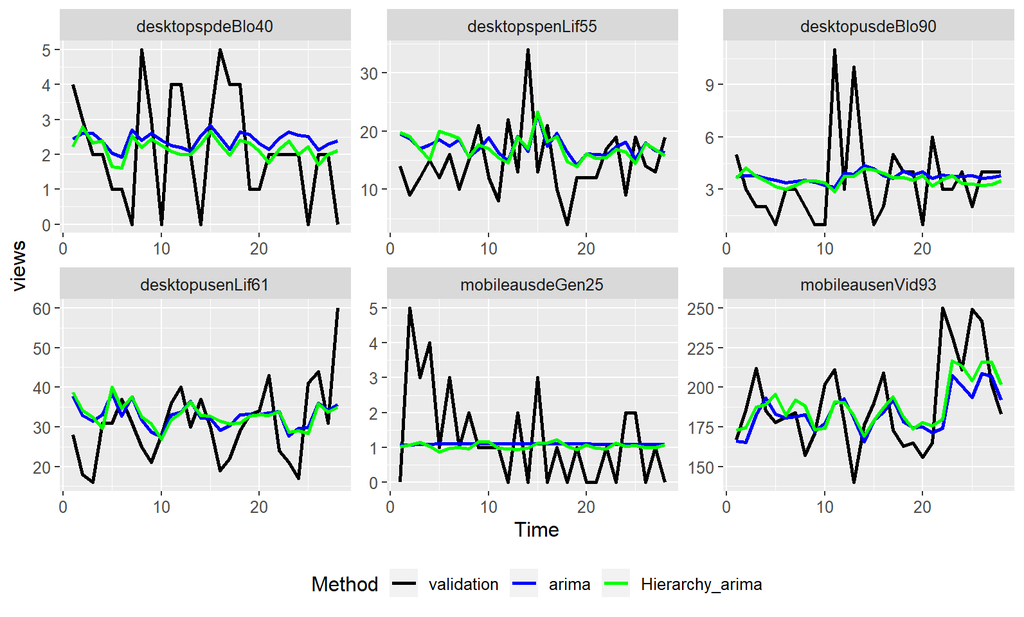

## WikipediaData: Comparing ets methods - with and without hierarchy - log(RMSE) Density plot

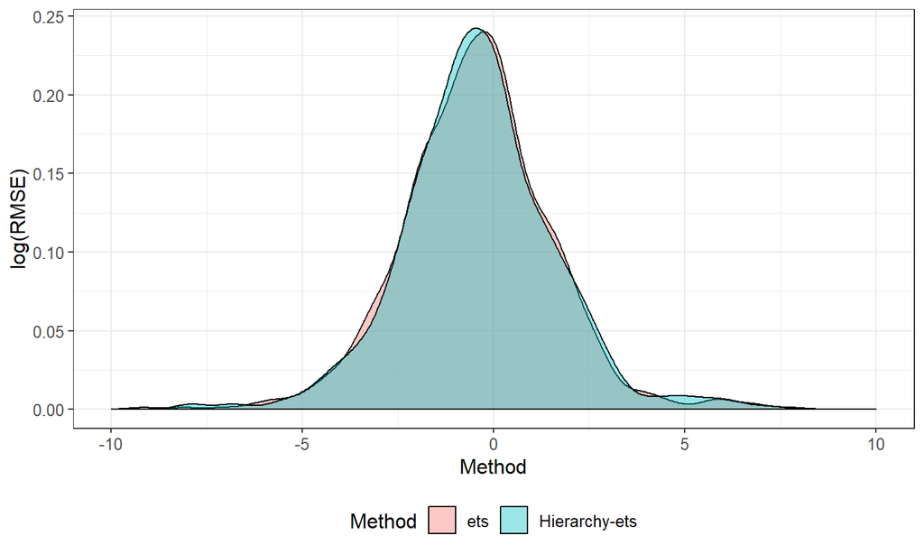

## WikipediaData: Comparing ets methods - with and without hierarchy - log(RMSE) Boxplot

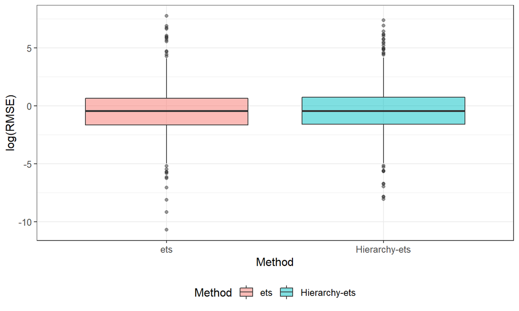

## WikipediaData: Comparing ets methods - with and without hierarchy - Subtracted log(RMSE) Boxplot

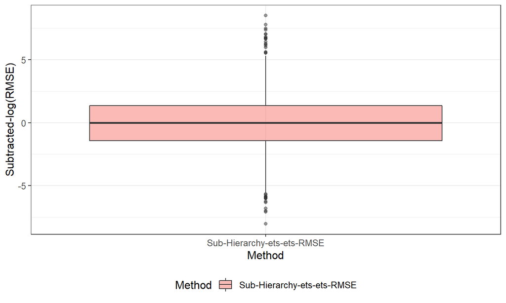

## WikipediaData: Comparing ets methods - with and without hierarchy - Error Density plot

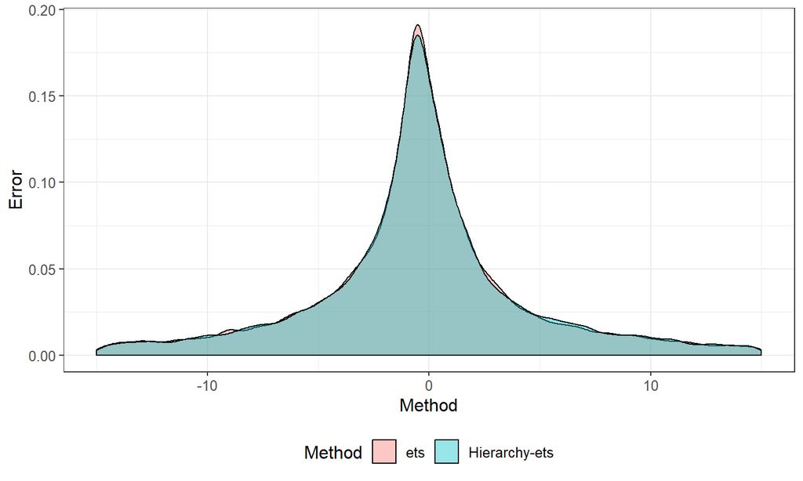

## WikipediaData: Comparing ets methods - with and without hierarchy - Error Boxplot

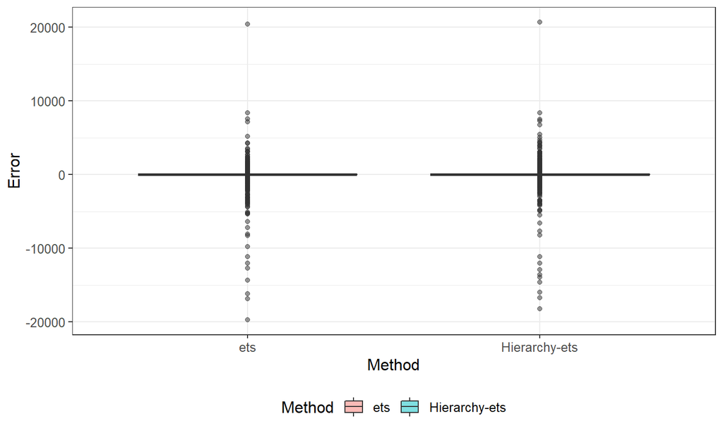

## WikipediaData: Comparing ets methods - with and without hierarchy - Subtracted Error Boxplot

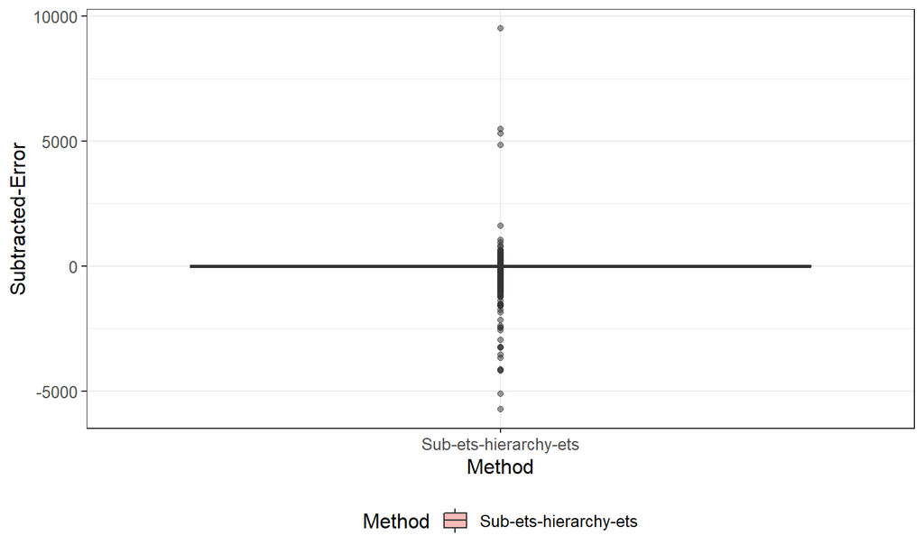

## WikipediaData: Comparing ets methods - with and without hierarchy - Forecasted Series Plot

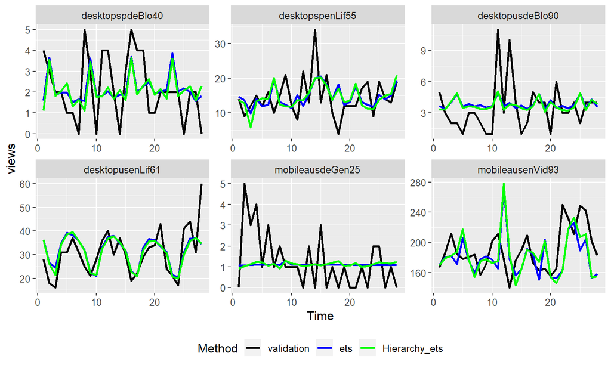

## Comparing OLS methods - with and without hierarchy - log(RMSE) Density plot

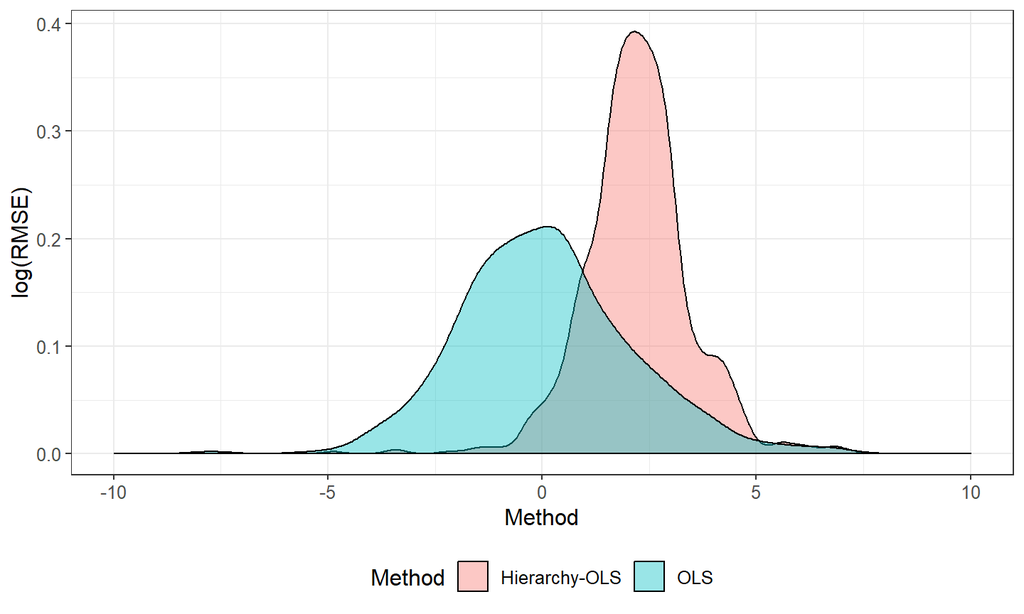

## WikipediaData: Comparing OLS methods - with and without hierarchy - log(RMSE) Boxplot

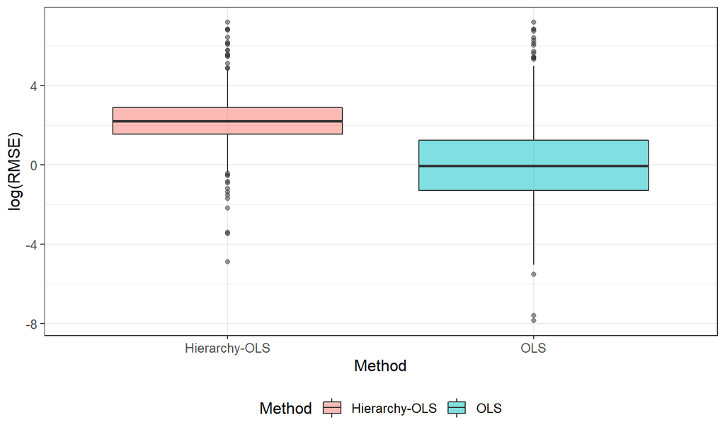

## WikipediaData: Comparing OLS methods - with and without hierarchy - Subtracted log(RMSE) Boxplot

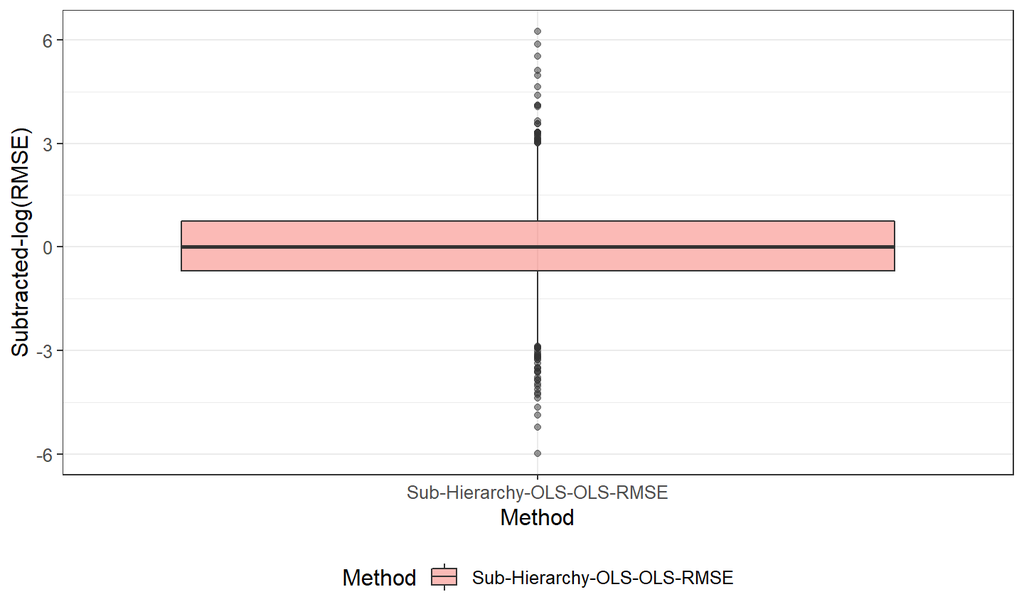

## WikipediaData: Comparing OLS methods - with and without hierarchy - Error Density plot

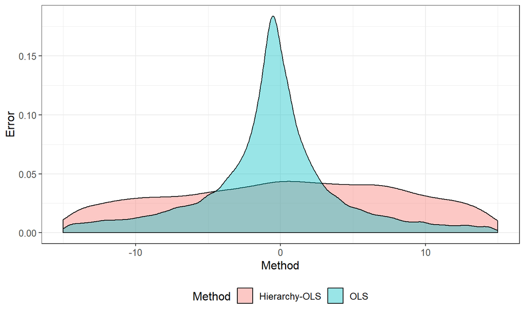

## WikipediaData: Comparing OLS methods - with and without hierarchy - Error Boxplot

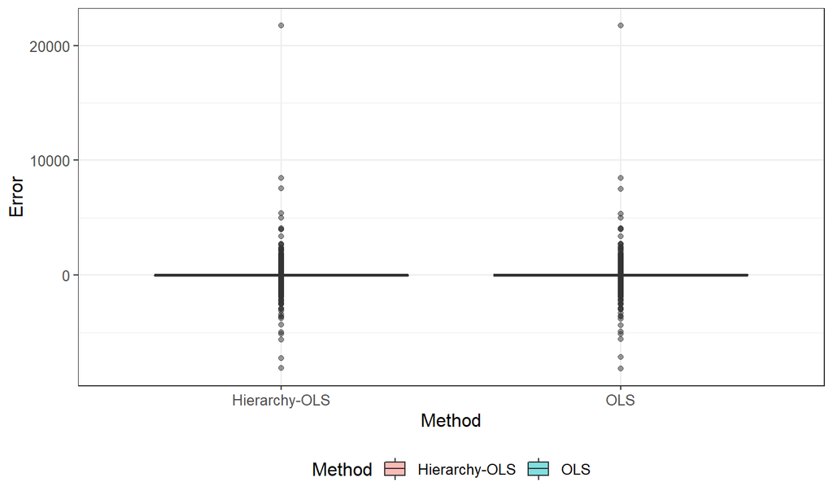

## WikipediaData: Comparing OLS methods - with and without hierarchy - Subtracted Error Boxplot

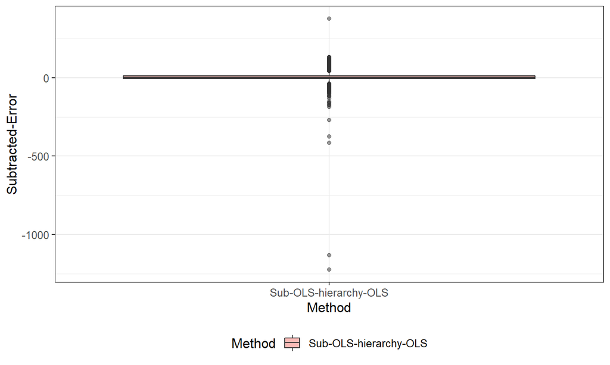

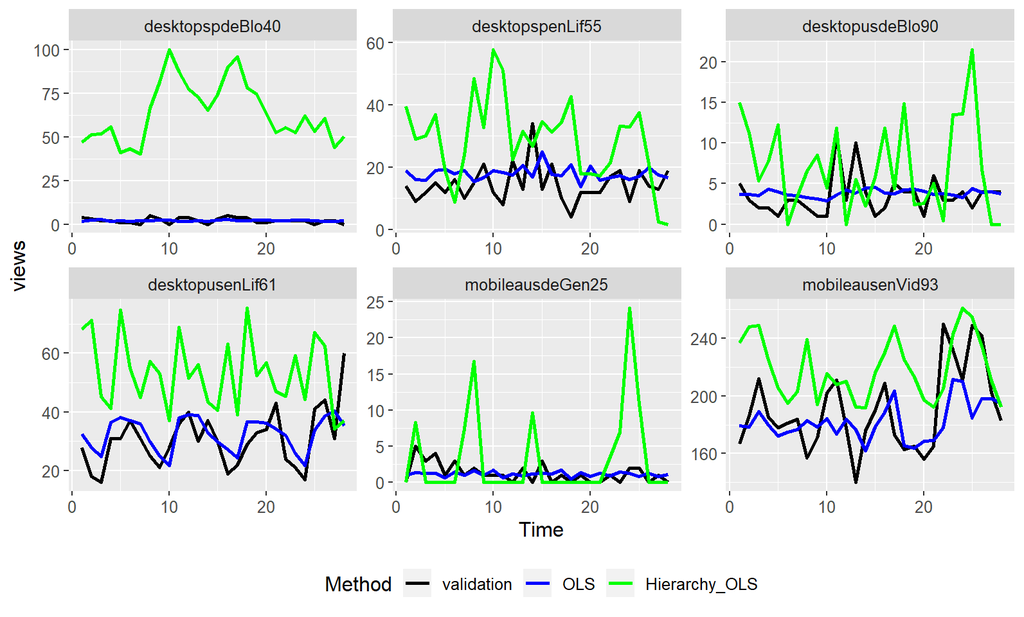

## WikipediaData: Comparing all methods - with and without hierarchy - log(RMSE) Density plot

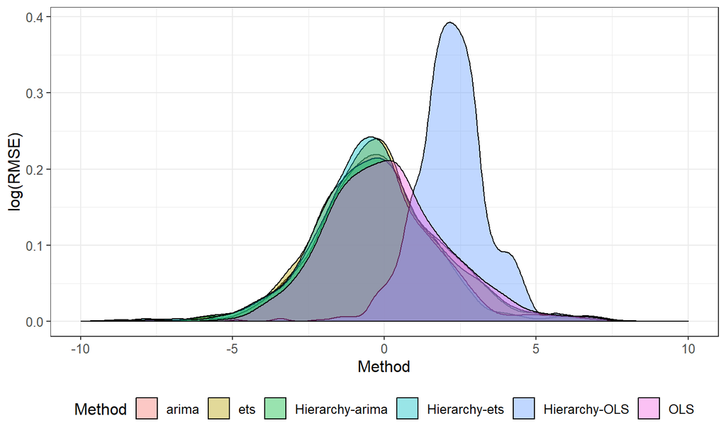

## WikipediaData: Comparing all methods - with and without hierarchy - log(RMSE) Boxplot

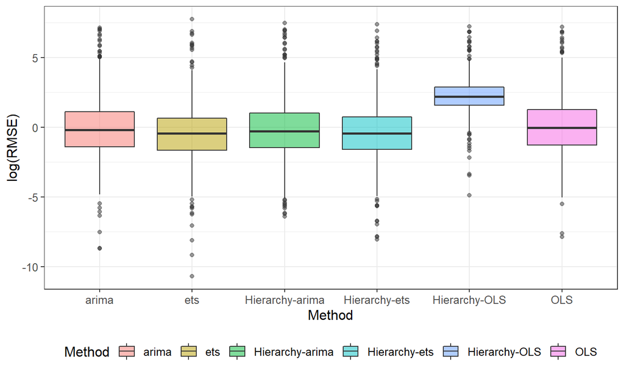

## WikipediaData: Comparing all methods - with and without hierarchy - Error Density plot

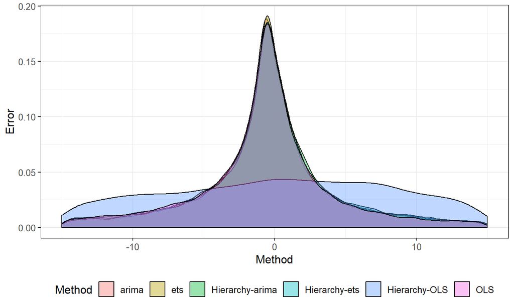

## WikipediaData: Comparing all methods - with and without hierarchy - Error Boxplot

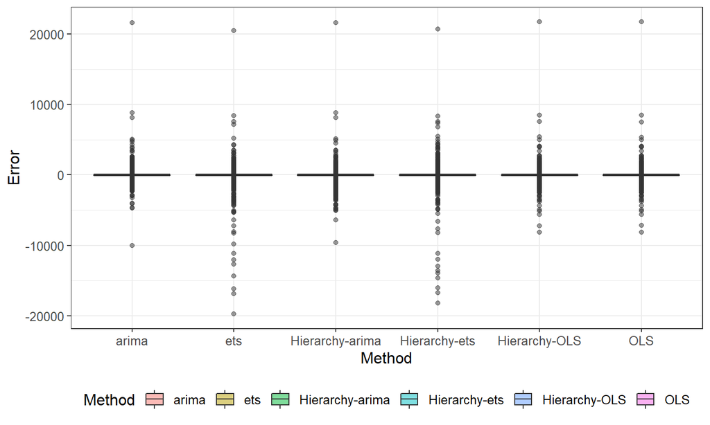

## WikipediaData: Comparing all methods - with and without hierarchy - Forecasted Series Plot

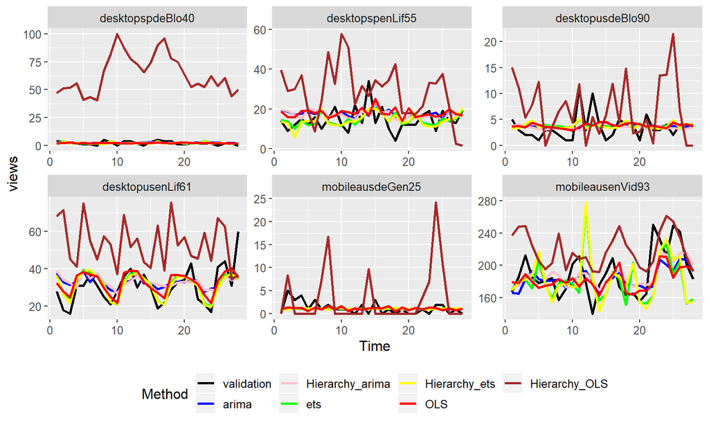